# Version Control and Collaborative development

2017-05-27

Version control makes it possible to have ‘unlimited undo’ and histories of your documents (and some smaller datasets)

Having everything on a website like GitHub (or Bitbucket or GitLab) makes it easy to share with other people and collaborate.

If you keep all of your important programs and files somewhere in the cloud, like on box.com, dropbox, github, it makes it easier to use heterogeneous environments.

## Version Control [SWC Git Novice 1-6](http://swcarpentry.github.io/git-novice/)

### Getting Started

Introduce yourself (once you’ve set this on your machine, you don’t have to set it again unless you want to change something):

```bash
git config --global user.name "Firstname Lastname"
git config --global user.email you@yourdomain.example.com
```

If you want your contributions to be recognized:

> Scott Rohde, Carl Crott, mulroony, David LeBauer, Jeremy Kemball, Rob Kooper, Jimmy Chen, andrewshirk, Zhengqi Yang, Max Burnette, MarvinJ, 董伊琳, Uday Saraf, The Gitter Badger and Michael Dietze (2016) “PecanProject/bety: BETYdb 4.13”. Zenodo. doi: 10.5281/zenodo.162409.

```bash
mkdir myproject
git init
```

The above command creates a hidden directory called `.git` that keeps tracks of changes in the directory. We now call it a “repository”" or “repo” for short. One maintains a log of changes with Git, but you have to tell it what to track. The command `git status` tells you, among other things, the status of changes to the directory:

```bash
git status
```

Since we created the empty repo, there shouldn’t be any changes to track yet, so let’s make a file:

```bash
echo "my project" > README.md
git status
```

### Commiting changes

Changes are tracked via “commits”, but you need to tell git which files to line up for the commit. The following code moves the file `README.md` to the “staging” are waiting to be committed:

```bash
git add README.md
git status
```

You then commit together with a short but descriptive message:

```bash
git commit -m "added README as first commit"
git status
```

### Git log

If at any time you want to know all that has been committed:

```bash
git log
```

### Branching

Branches are a powerful aspect of git, they are like an “alternative history” in which you can make changes. You can later decide if you want to merge these changes into the “main timeline”.

The “main timeline” is itself a branch called “master”.

A branch called “first-script” can be created with:

```bash
git branch first-script
```

You don’t automatically change to this branch. For that:

```bash
git checkout first-script
```

You can return to the master branch by:

```bash
git checkout master
```

The `git status` command tells you what branch you are on.

A shorter way to create a branch and simultaenously switch to it is:

```bash
git checkout -b first-script
```

This creates a new branch called your ‘first script’. Now lets add something to it.

```bash
echo "!#/bin/bash \n echo 'hello world'" > myscript.sh
```

Quick-check question: * What is `\n`?

Now commit the changes:

```bash
git add myscript.sh
git commit -m 'added hello world script'
```

### Merging

Once you’re satisfied with changes you can merge the branch with the master branch. You do this from the branch you want to merge into, in this case from master. It’s good practice to use `git status` at every step to check what branch you are on and any changes you may have not committed.

```bash
git status
git log
git checkout master
git status
git merge first-script
git status
```

Note this does not delete the branch.

### Review

You may want to know all commits and the branches in which they were made in. As mentioned before, `git log` gives you a history. Adding the `--graph` flag give you a history of commits together with an asterisk `*` telling you to what branch the commit belongs to.

```bash
git log --graph
```

## Collaborative Coding [SWC Git Novice 7-14](http://swcarpentry.github.io/git-novice/)

One of the strenghts of git is its power to facilitate collaboration.

### GitHub

GitHub is one of the many hosting sites for collaborative coding via Git. You can create a repo in their servers via their website, and then clone it onto your computer via:

```bash
git clone url-of-repo-goes-here
```

One works on it locally as you would a local git repo. But after committing changes you need to send them to the repo on the server using:

```bash
git push
```

Multiple people can do this, so you should periodically “pull” changes:

```bash
git pull
```

There may be conflicts. For the mechanics of resolving such things we refer to the software carpentry notes.

### Pull Requests & Code Reviews

It’s best practice to work with branches, and then to submit a “pull request” on the Github site of your repo. This opens up a forum to discuss the code.

The branch can be pulled via a `git pull` and then revealed by:

```bash
git branch -a
```

The branch can be checked out by a `git checkout` and viewed.

Your collaborators then review the code. Those with push access may commit and push changes. The discussion happens on the website. Even individual lines of code can be commented.

When everybody is satisfied with the new code, it can get accepted and merged to the master branch right from the website (or the command line too).

### Messaging

- Slack
- IRC

## Git in Practice

There are various workflows based around git. The following is a very common approach to using Git. It is described in a blog post by Vincent Dressen http://nvie.com/posts/a-successful-git-branching-model/.

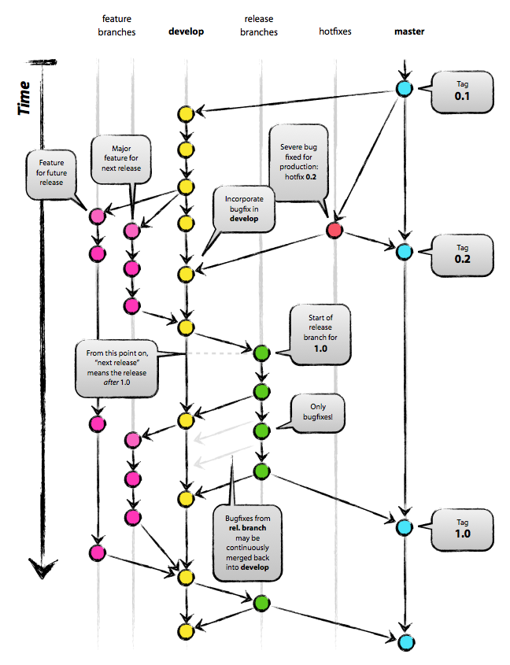

image of git workflow

We use this in the PEcAn Project. Here is a [list of branches](https://github.com/PecanProject/pecan/branches/all). Our documentation provides a [recommended git workflow](https://pecanproject.github.io/pecan-documentation/using-git.html#recommended-git-workflow) that includes a ‘basic’ and ‘advanced’ section. These are worth reading, and it is not necessary to include the content here.

Google is where you will often turn for help, and Google will often lead you to [Stackoverflow.com](https://stackoverflow.com). If you read through the most popular [stackoverflow questions tagged with ‘git’](https://stackoverflow.com/questions/tagged/git) you will find solutions to most common problems.

### Git in Rstudio

At www.pi4-uiuc open the Rstudio environment.

To add the git repo: In top corner Project –> New Project –> Version Control –> https://www.github.com/username/repository

To create a new R script: > File –> New File –> R Script

Commits and pushes can be made directly from RStudio.